# Bootstrap

Sometimes, we have a statistic that we don’t have a theoretical distribution for. (What. did. you. just. say. ?!) Okay. Let’s rewind.

Everything that we’ve been testing till this point has been some function of the data. Think about it. To get a mean, we sum up all of the data, then divide by the number of data points we have ($n$. To get a proportion, we count up all of the values that have a trait, then divide by $n$.

Recall your **IQR**. How did we calculate that? We took the number of data points above and below to make sure there were 25% above and below. While this does have to do with $n$, our calculation of Q1, Q2, and Q3 have nothing to do with what values the data points represent. The calculations only have to do with their positioning.

When we made confidence intervals, we were using the sampling distribution of a statistic to create them (whether you knew it or not!). Let’s make a confidence interval just to prove a point.

## 95% confidence interval for $\mu$

Imagine we have these data. Say that we *know* the population standard deviation is 1.

```r
set.seed(1420)

# * RANDOMLY SELECT SOME VALUES TO TEST
our_random_data <- c(runif(n=15, min=-1, max=1),
                     rnorm(n=25, mean=0, sd=1),
                     rpois(n=5, lambda=1))

# * PUT THEM INTO A DATAFRAME
our_random_data <- data.frame(observations=our_random_data)

# * PREVIEW THE DATA
head(our_random_data, 10)
```

```
##    observations
## 1     0.1441869
## 2    -0.3051921
## 3    -0.9847641
## 4     0.9180716
## 5     0.7938969
## 6     0.8199566
## 7     0.7434245
## 8     0.1938048
## 9    -0.3769535
## 10   -0.5710744
```

Let’s look at the histogram of these data to test some assumptions. We are interested in using a normal-based confidence interval on these data because (1) we are assuming they are an SRS, (2) they are independent from one another, and (3) we know the population standard deviation $\sigma=1$.

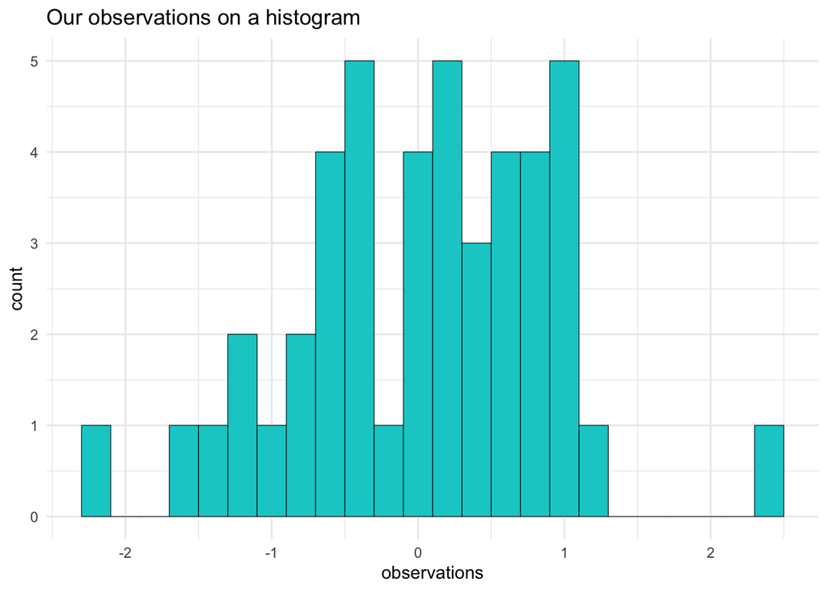

```r
library(ggplot2)
ggplot(our_random_data, aes(x=observations)) +
  geom_histogram(binwidth=0.2, col="black", fill="cyan3", lwd=0.2) +
  ggtitle("Our observations on a histogram") +
  theme_minimal()
```

These data can pass for normal.

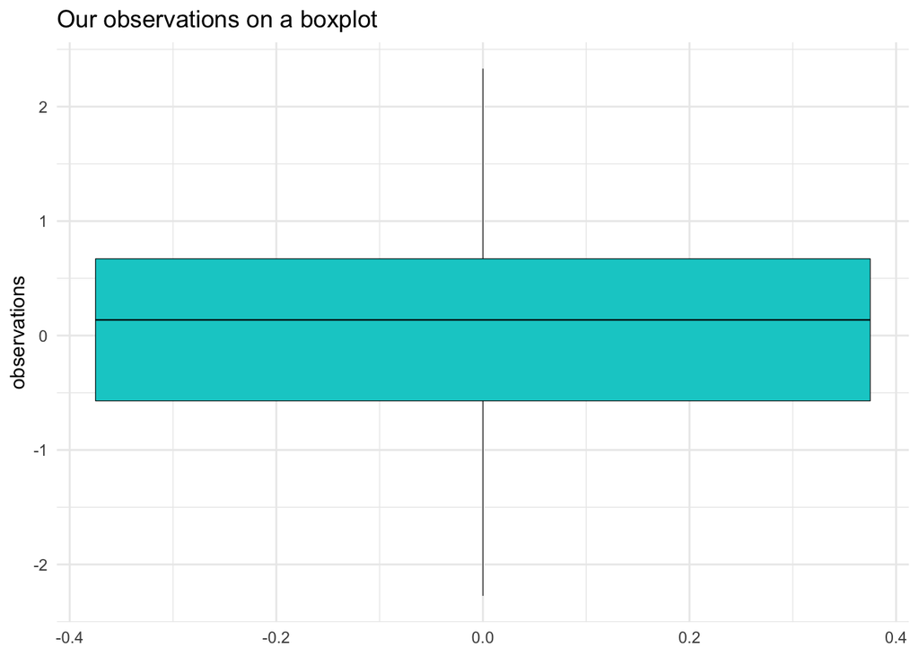

```r
ggplot(our_random_data, aes(y=observations)) +
  geom_boxplot(col="black", fill="cyan3", lwd=0.2) +
  ggtitle("Our observations on a boxplot") +
  theme_minimal()
```

We’re now pretty confident about testing the hypotheses using a normal-based interval.

$$H_0: \mu = 1$$
versus

$$H_1: \mu \neq 1$$

Let’s go ahead with the confidence interval.

```r
library(dplyr)
n    <- nrow(our_random_data)
mean <- mean(our_random_data %>% pull(observations))
s    <- sd(our_random_data %>% pull(observations))
crit <- qnorm(p=0.975)
```

With the above calculated values, we can use the following information from a sampling distribution of $\mu$ which is, under the right conditions, $N(\mu, \sigma^2/n)$. That is,

$$E(\bar{x}) = \mu$$

and

$$SD(\bar{x}) = \hat{SE} = \frac{\sigma}{\sqrt{n}} = \frac{1}{\sqrt{n}}.$$

Thus, our 95% confidence interval is of the form

$$\bar{x} \pm z_{\alpha/2}\frac{\sigma}{\sqrt{n}}$$

And we calculate it to be

```r
n     <- nrow(our_random_data)
sigma <- 1
z     <- qnorm(p=0.975)
x_bar <- mean(our_random_data$observations)

# * STANDARD ERROR
se    <- sigma / sqrt(n)

# * MARGIN OF ERROR
me    <- z*se

# * INTERVAL
c(x_bar-me, x_bar+me)
```

```
## [1] -0.2633498  0.3209986
```

We hypothesized that $\mu=1$. As we see in the plot below, this value is way outside of our 95% normal-based confidence interval.

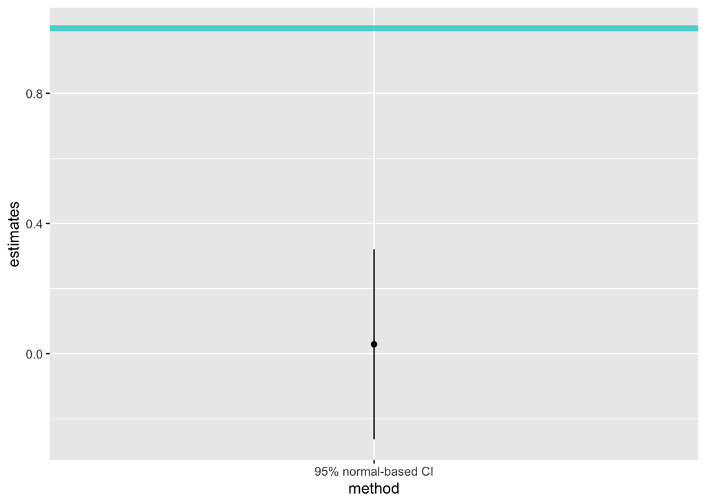

```r
# * CREATE FORMATTED OBJECT TO PLOT
library(tibble)
CI <- tibble(method   = "95% normal-based CI",
             lower = -0.2633498,
             upper = 0.3209986,
             estimate = x_bar)

# * PLOT
ggplot(data = CI, aes(x = method, y = estimate)) +
  geom_point() +
  geom_segment(aes(x = method, xend = method, y = lower, yend = upper)) +
  labs(y = "estimates") +
  geom_hline(aes(yintercept = 1), lwd=2, col="cyan3", alpha=0.75)
```

We have evidence here to reject $H_0$ because $1 \notin (-0.2633498, 0.3209986)$. Our corresponding $\alpha=0.05$ level hypothesis test would yield the same conclusion; the p-value for this correspoding HT would be smaller that 0.05.

## 95% confidence interval for $m$

What if we wanted to test

$$H_0: m = 1$$
versus

$$H_1: m \neq 1$$

where $m$ is the median. Then, we’d definitely be interested in creating one of these bad boys

$$\bar{x} \pm z_{\alpha/2}\frac{\sigma}{\sqrt{n}}$$

for $m$. How would we do that? Certainly, we would replace $\bar{x}$ for $\hat{m}$ (our sample median), but after that, I don’t know what we’d use for our margin of error because we don’t have a theoretical sampling distribution for $m$ like we do for $\bar{x}$ or $p$. But what do we always do when we don’t have the truth? We estimate it the best we can. This is statistics after all!

**For statistics like the median that we do not have a theoretical sampling distribution for, we can use resampling to SIMULATE a sampling distribution**!

First, let’s use our *original sample* to calculate a median.

```r
observed_median <- median(our_random_data %>% pull(observations))
observed_median
```

```
## [1] 0.1366614
```

Now, let’s **simulate a new dataset**. Because we have assumed that our sampling practices have given us a sample *representative* of our population of interest, we can create a new sample from our original one. We do this by sampling from our original *with replacement*. We use the following code to do this.

```r
resample_ex <- our_random_data %>% sample_n(nrow(our_random_data), replace=TRUE)
head(resample_ex)
```

```
##   observations
## 1   -0.7012219
## 2   -1.3099168
## 3    0.5060775
## 4   -0.6797058
## 5    1.0000000
## 6   -0.6196262
```

Notice that

```r
dim(resample_ex)
```

```
## [1] 45  1
```

and

```r
dim(our_random_data)
```

```
## [1] 45  1
```

give the same output. That is, we have the same number of observations in our original sample as our simulated resample. Now, we’ll calculate the median.

```r
median(resample_ex %>% pull(observations))
```

```
## [1] 0.04716104
```

If we keep (1) creating a new sample from our original sample and (2) calculating a sample median, then we can use all of the medians we calculate to simulate a sampling distribution. Recall that we previously created sampling distributions for $\mu$ by calculating a bunch of $\bar{x}$ and visualizing them with a histogram.

I’m going to use the following function to take many resamples and calculate the median of my original data with replacement.

```r
# * FUNCTION FOR RESAMPLE + MEDIAN CALCULATION
bootstrap_medians <- function(original_dataset, number_resamples) {
  sapply(1:number_resamples, function(x) {
    this_resample <- original_dataset %>% sample_n(nrow(original_dataset), replace=TRUE)
    median(this_resample %>% pull(observations))
  })
}

# * APPLY FUNCTION
medians <- bootstrap_medians(our_random_data, 9000)
```

Now that we have done a bunch of calculations, we will plot our sampling distribution on a histogram.

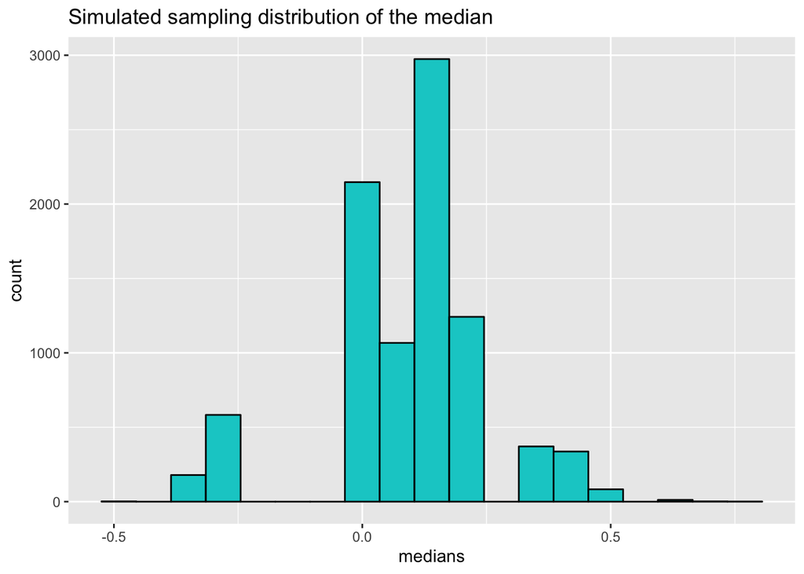

```r
simulated_sampling_dist <- data.frame(medians)
ggplot(simulated_sampling_dist, aes(x=medians)) +
  geom_histogram(binwidth=0.07, col="black", fill="cyan3") +
  ggtitle("Simulated sampling distribution of the median")
```

### In a normal scenario

To create a confidence interval, we need to think about what the margin of error is in a normal-based confidence interval. The margin of error uses two pieces (1) critical z-value and (2) your standard error. Recall for a $(1-\alpha)100\%=95\%$ confidence interval, we use the critical z-value of 1.96.

```r
alpha <- 0.05
z     <- qnorm(1-(alpha/2))
round(z, 2)
```

```
## [1] 1.96
```

We get this value by asking `R`, which x-value along a standard normal distribution $N(0,1)$ will give us 2.5% probability above it? Likewise, we can think of the other side of things. What x-value will give us 2.5% probability below it on a $N(0,1)$?

```r
minus_z <- qnorm(alpha/2)
round(minus_z, 2)
```

```
## [1] -1.96
```

Now that we have the two values that will give us 5% in the tails, we want to *multiply by our standard error*. Remember how we use standardization techniques to go from a normal distribution with arbitrary $\mu_A$ and $\sigma_A$ to $N(0,1)$ by using $z=\frac{x-\mu_A}{\sigma_A}$? This is like going backwards. We want to know which x-value along our SAMPLING DISTRIBUTION will give us 2.5% probability above/below it. Multiplying our critical z by our standard error allows us to calculate this.

From there, we could calculate our lower and upper bound by adding to our sample mean:

$$\bar{x} + (-1.96)\frac{\sigma}{\sqrt{n}}$$

and

$$\bar{x} + (1.96)\frac{\sigma}{\sqrt{n}}$$

which gives us

$$\bar{x} \pm (1.96)\frac{\sigma}{\sqrt{n}}$$

which looks all too familiar at this point. But, remember… we’re not working in a setting where we (1) don’t have population $\sigma$ known to us and (2) don’t have the normal distribution at our disposal.

### In a non-normal, non-parametric scenario

We can’t calculate a critical z for our simulated sampling distribution. However, we can instead use quantiles to estimate our lower and upper bounds!

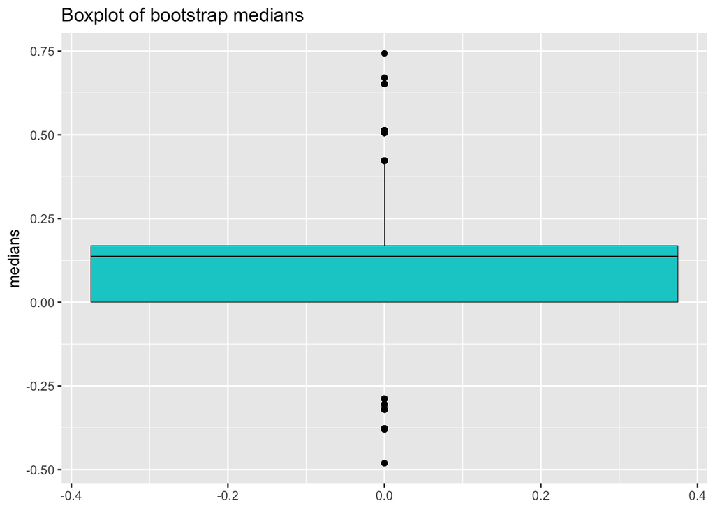

```r
ggplot(simulated_sampling_dist, aes(y=medians)) +
  geom_boxplot(col="black", fill="cyan3", lwd=0.2) +
  ggtitle("Boxplot of bootstrap medians")
```

We can use the `quantile()` function to ask for the data point that will give us 2.5% below it and the data point that will give us 2.5% above it.

```r
simulated_sampling_dist %>% summarize(lower=quantile(medians, 0.025),
                                      upper=quantile(medians, 0.975))
```

[output not shown]

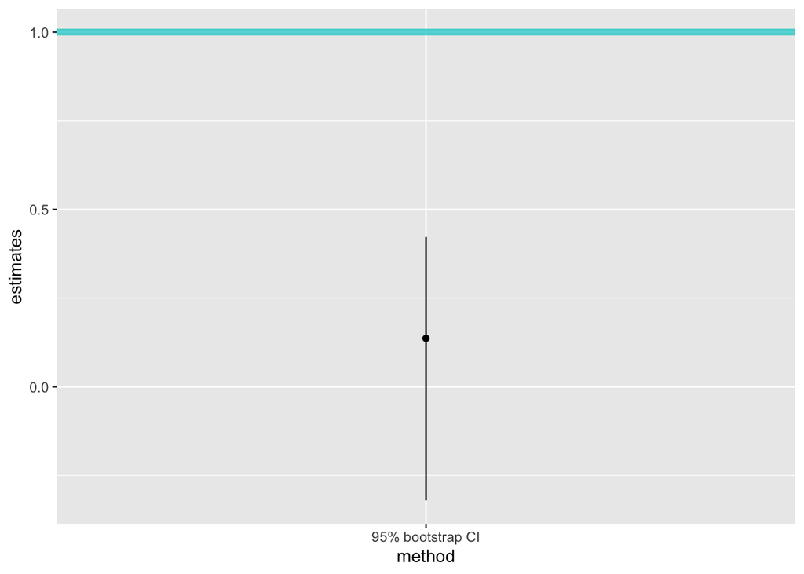

```r
# * CREATE FORMATTED OBJECT TO PLOT
library(tibble)
CI <- tibble(method   = "95% bootstrap CI",
             lower = -0.320534,
             upper = 0.4223171,
             estimate = observed_median)

# * PLOT
ggplot(data = CI, aes(x = method, y = estimate)) +
  geom_point() +
  geom_segment(aes(x = method, xend = method, y = lower, yend = upper)) +
  labs(y = "estimates") +
  geom_hline(aes(yintercept = 1), lwd=2, col="cyan3", alpha=0.75)
```